# General Assembly, NY

### Mutate, Transform (`apply`)

One approach would be to directly use values from other columns to derive new columns. The other would be to apply functions to columns using a named or lambda function.

You can generate the new columns by defining their name as a key.

```python
nyt['column_of_ones'] = 1

nyt['saw_ad_many_times'] = nyt['Impressions'].apply(lambda x: 1 if x > 5 else 0)

def saw_add_func(x):
    if x > 5:
        return 1
    else:
        return 0

nyt['saw_ad_many_times'] = nyt['Impressions'].apply(saw_add_func)

# practice on one column:
# a common approach to missing data, let's either set the values to null, or -1:
# import numpy as np
# np.nan


# by default apply works with a single column, however you can use it to iterate by row as well (though it is slower)
nyt['not_signed_in'] = nyt.apply(lambda row: 0 if row['Signed_In'] else 1, axis=1)
```

### Pivot and Aggregate

Earlier we saw use of the function `groupby`. A pandas groupby object has other functionality, such as returning statistics about a column, or all columns, or aggregating only what's defined.

Similarly, pivot tables can be used to explore groups side by side.

```python
import numpy as np
nyt['column_of_ones'] = 1
nyt['Click_Thru'] = nyt['Clicks'] / nyt['Impressions']
nyt['Click_Thru'] = nyt['Click_Thru'].apply(lambda x: 0 if x == np.inf else x)
nyt_signedin_only = nyt[nyt.Signed_In == 1]
nyt_group = nyt.groupby('Age')

print nyt_group.mean()
```

```
       Gender  Impressions    Clicks  Signed_In  column_of_ones  \
Age
0    0.000000     4.999657  0.142080          0               1
7    0.200000     5.200000  0.600000          1               1
8    0.800000     6.266667  0.266667          1               1
9    0.666667     5.520833  0.104167          1               1
10   0.716814     4.814159  0.168142          1               1
11   0.671378     5.095406  0.127208          1               1
12   0.658703     4.885666  0.156997          1               1
13   0.688385     4.995279  0.149197          1               1
14   0.690338     5.035506  0.133877          1               1
15   0.673704     4.944338  0.150480          1               1
16   0.695033     4.990125  0.151612          1               1
17   0.684290     5.060207  0.152795          1               1
18   0.533186     4.978060  0.084440          1               1
```

[output cut: 114 more lines]

```python
print nyt_group['Click_Thru'].mean()
```

```
Age
0      0.028163
7      0.161905
8      0.047727
9      0.015410
10     0.037927
11     0.024330
12     0.032845
13     0.032343
14     0.027167
15     0.031154
16     0.029977
17     0.029798
18     0.017216
19     0.009459
```

[output cut: 18 more lines]

```python
print nyt_group.agg({
    'Click_Thru': ['mean', 'max'],
    'Gender': 'mean',
})
```

```
       Gender  Click_Thru
         mean        mean       max
Age
0    0.000000    0.028163  1.000000
7    0.200000    0.161905  0.333333
8    0.800000    0.047727  0.333333
9    0.666667    0.015410  0.200000
10   0.716814    0.037927  0.500000
11   0.671378    0.024330  0.500000
12   0.658703    0.032845  1.000000
13   0.688385    0.032343  1.000000
14   0.690338    0.027167  0.666667
15   0.673704    0.031154  1.000000
16   0.695033    0.029977  1.000000
17   0.684290    0.029798  1.000000
```

[output cut: 51 more lines]

```python
print nyt[nyt.Signed_In == 1].pivot_table(
    values='column_of_ones',
    index='Gender',
    columns='Age',
    aggfunc='count'
)
```

```
Age     7    8    9    10   11   12   13    14    15    16   ...   97   98   \
Gender                                                       ...
0         4    3   16   32   93  200  330   532   850  1050  ...     7    9
1         1   12   32   81  190  386  729  1186  1755  2393  ...     7    6

Age     99   100  101  102  103  104  107  108
Gender
0         5    1    2  NaN    1  NaN  NaN    1
1         4    3    2    2    1    1    2  NaN

[2 rows x 100 columns]
```

Practice:

1. Aggregate the mean and standard deviation (std) of Age when Signed_In equals 1
2. Find the min values of Age for each value of Impressions
3. Find the max values of Clicks for each value of Impressions
4. Determine: Are Signed In users more or less likely to click thru on an ad?

## plotting

matplotlib's core functionality serves as a plotting tool within python. While calling .describe() on DataFrames is useful to get a rough idea of what your data looks like, plots allow you to visualize what your data really looks like. For today, we'll use matplotlib within the context of pandas.

Consider the following data set and code:

```python
anscombe = pd.DataFrame({
    'x' :  [10, 8, 13, 9, 11, 14, 6, 4, 12, 7, 5],
    'y1' : [8.04, 6.95, 7.58, 8.81, 8.33, 9.96, 7.24, 4.26, 10.84, 4.82, 5.68],
    'y2' : [9.14, 8.14, 8.74, 8.77, 9.26, 8.10, 6.13, 3.10, 9.13, 7.26, 4.74],
    'y3' : [7.46, 6.77, 12.74, 7.11, 7.81, 8.84, 6.08, 5.39, 8.15, 6.42, 5.73],
    'x4' : [8,8,8,8,8,8,8,19,8,8,8],
    'y4' : [6.58,5.76,7.71,8.84,8.47,7.04,5.25,12.50,5.56,7.91,6.89],
})

anscombe.describe()
```

|  | x | x4 | y1 | y2 | y3 | y4 |
| --- | --- | --- | --- | --- | --- | --- |
| count | 11.000000 | 11.000000 | 11.000000 | 11.000000 | 11.000000 | 11.000000 |
| mean | 9.000000 | 9.000000 | 7.500909 | 7.500909 | 7.500000 | 7.500909 |
| std | 3.316625 | 3.316625 | 2.031568 | 2.031657 | 2.030424 | 2.030579 |
| min | 4.000000 | 8.000000 | 4.260000 | 3.100000 | 5.390000 | 5.250000 |
| 25% | 6.500000 | 8.000000 | 6.315000 | 6.695000 | 6.250000 | 6.170000 |
| 50% | 9.000000 | 8.000000 | 7.580000 | 8.140000 | 7.110000 | 7.040000 |
| 75% | 11.500000 | 8.000000 | 8.570000 | 8.950000 | 7.980000 | 8.190000 |
| max | 14.000000 | 19.000000 | 10.840000 | 9.260000 | 12.740000 | 12.500000 |

Visually from creating the data frame you can tell the data looks different, yet in the .describe() call, the data shares very similar features. The two primary plotting tools we uses from matplotlib are histograms and scatterplots, which help us understand the shape of data.

```
Axes(0.125,0.125;0.775x0.775)
Axes(0.125,0.125;0.775x0.775)
Axes(0.125,0.125;0.775x0.775)
Axes(0.125,0.125;0.775x0.775)
```

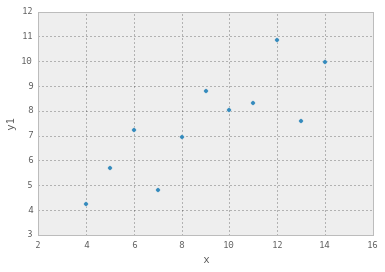

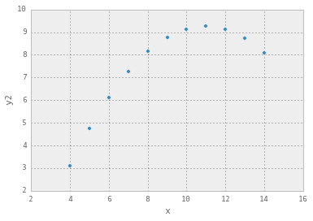

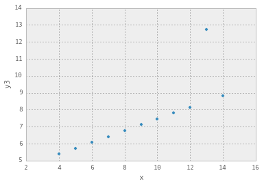

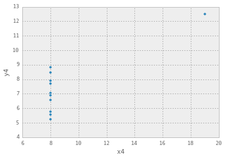

```python
%matplotlib inline
# above magic allows plots to show in our notebook.
pd.options.display.mpl_style = 'default'

for y in ['y1', 'y2', 'y3', 'y4']:
    if y != 'y4':
        print anscombe.plot(kind='scatter', x='x', y=y)
    else:
        print anscombe.plot(kind='scatter', x='x4', y=y)
```

Use these new tools in order to visualize some of this New York Times ad performance data.

```
Axes(0.125,0.125;0.775x0.775)
```

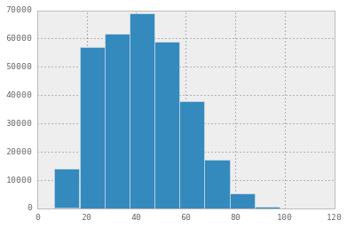

```python
print nyt[nyt.Signed_In == 1].Age.hist()
```

```
Axes(0.125,0.125;0.775x0.775)
```

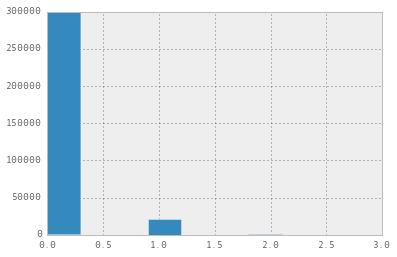

```python
print nyt[nyt.Signed_In == 1].Clicks.hist()
```

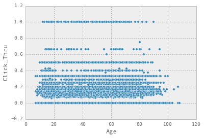

```python
nyt[nyt.Signed_In == 1].plot(kind='scatter', x='Age', y='Click_Thru')
```

## Independent Practice

Practice doing much of the same functionality we did today with two of the four different data sets from here in small groups of 3 or 4.

Primarily, your goals are to:

- Show how to load a csv file into python
- Use pandas to understand the numerical portions of the data
- Use matplotlib to visualize the data
- Use scikit-learn to fit the data to some dependent feature (y)

Summarise your work with the following questions:

1. What is the dataset about? What do the columns mean?
2. What does the dataset look like?
3. What data relationships can you find?
4. Given those relationships/correlations, what does that help explain or help you understand about the data?

We will come back as a class and have each group present their answers to the above to one of the data sets they explored.

## Next Steps

I encourage you to pick up and start reading the following books to continue learning about programming and data analytics.

**Still uncomfortable with Python?**  
That's okay! Continue practicing your python basics with [Learn Python the Hard Way](http://learnpythonthehardway.org/book/). It'll strengthen your chops. Do it multiple times—you'll keep learning!

**Feel like Pandas can revolutionize how you work?**  
Purchase and read Wes McKinney's [Python for Data Analysis](http://shop.oreilly.com/product/0636920023784.do). It'll get you cranking on everything Wes did with Pandas and why it was designed the way it was.

**Want to dig into why Data Science?**  
Check out Provost and Fawcett's [Data Science for Business](http://www.amazon.com/Data-Science-Business-data-analytic-thinking/dp/1449361323). You'll start understanding more about the business practice of Data Science (vs the academic side) and some fundamentals about algorithm and stats application.